# Logistics

## 1. Partners

We have identified three operational partners:

- **GEOBON-International contributors**. This group includes not only contributors from the GEO BON international community but other international experts (currently not affiliated to GEO BON) that can provide valuable insights on multiple topics of this initiative. **Using multiple cases studies**, this group will present which models and tools are available within and outside the GEO BON international community aimed to inform decision making and policy to protect, manage and monitor biodiversity, ecosystem services (i.e., carbon storage) and traditional food security (e.g., freshwater fisheries, foraging wild fruits). Case studies will illustrate what methods, models and tools have successfully worked. Moreover, What methods, models and tools have not worked? and Why?
- **Regional experts.** This group will provide an evaluation of whether or not:
  - These models and tools are feasible to apply in this region.
  - The data sets currently available are enough for applying proposed models and tools.
  - Bring to the discussion some Canadian case studies (and others regional experts might know).
- **Implementers/users**: PC, ECCC, Indigenous partners, Provincial (MB, ON, QC). This group will promote a discussion with all partners to answer these questions, among others:
  - How can local, regional and national partners can implement the proposed models and tools?
  - What are pros, cons, trade-offs and assumptions to integrate them into decision making?
  - What can be done now (tactical) and in the future?
  - How can we inform decision-making based on the best available data?

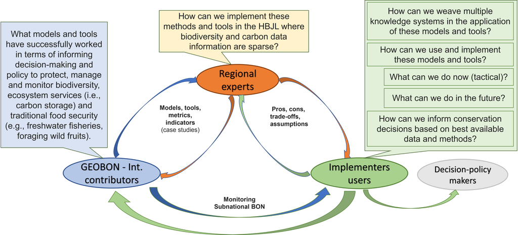

## 2. Pre-workshop activities

We expect GEO BON international contributors to **compile case studies** to show which methods, models and tools are available to inform decision making and policy to protect, manage and monitor biodiversity, ecosystem services (i.e., carbon storage) and traditional food security (e.g., freshwater fisheries, foraging wild fruits).

In general, we are looking to describe case studies with this minimum content:

- Short description, including local/region context, communities involved, conservation issues, communities expectations, etc
- Actions taken (management, policy-making, monitoring, community-based engagement, etc)
- Results, impacts and lessons learned (positive, negative and unexpected)
- References (papers, websites, grey literature, etc).

GEO BON has a supporting team (see below) that is currently compiling some case studies and we will be happy to support international contributors in in organizing their findings on this website. We will publish them as they become available.

## 3. Workshop

We will held a workshop with all partners.

- **Date**: October 16 and 17, 2023 (Monday and Tuesday)
- **Place and venue**: Montreal (venue TBD)

We expect a **stocktaking exercise, case study analysis**, and the outcome of the workshop with recommendations on appropriate tools and models, including the weaving of Traditional Knowledge into these that could be applied in the Hudson Bay-James Bay Lowlands.

We expect to have **breakout groups** and **plenary sessions**.

## 4. Potential Invitees

**In progress…….**

This is a preliminary distribution of potential invitees:

- Facilitator: 1
- Implementers: 15
- Regional experts : 15
- GEOBON International contributors.: 15
- GEOBON planning team: 3
- GEOBON local floating invitees for specific topics: 15

**Facilitator**

[output not shown]

**GEO BON**

#### **Integrating knowledge systems**

| **Name** | **Contribution** | **Organization/Affiliation** |
| --- | --- | --- |
| Myrle Ballard | Bridge, braid, and weave Indigenous science with western science approaches to inform and enhance decision-making | [ECCC - Indigenous Science division](https://science.gc.ca/site/science/en/blogs/science-behind-scenes/introducing-ecccs-new-director-indigenous-science), University of Manitoba |
| Norma Kassi (TBC) | [Indigenous Leadership Initiative](https://www.ilinationhood.ca/) Community-Based Research | [Canadian Mountain Network](https://www.canadianmountainnetwork.ca/about/directory/norma-kassi), Adjunct professor McGill |

#### **Carbon storage measuring, modelling, methods and tools**

| Kristell Hergoualc’h | Integrating peatland into national policy Peruvian Amazonian/Indonesian peatlands | [Center for International Forestry Research (CIFOR)](https://www.cifor.org/research-staff/2785/kristell-hergoualch) [CIRAD France](https://www.cirad.fr/en/about-us/cirad-in-a-nutshell) |
| --- | --- | --- |
| Catherine Farrell | [Peatlands](https://oneecosystem.pensoft.net/article/76838/element/8/129393//) [Irish Natural Capital Accounting for Sustainable Environments](https://www.incaseproject.com/) | [Trinity College Dublin](https://www.tcd.ie/Botany/people/catherine_f.php) [INCASE project](https://www.incaseproject.com/) |

#### **Traditional food security (e.g., freshwater fish and foraging wild foods)**

| Murray Humphries | Center for Indigenous Peoples’ Nutrition and Environment | [McGill University](https://www.mcgill.ca/nrs/academic-0/humphries), [Canadian Mountain Network](https://www.canadianmountainnetwork.ca/) |
| --- | --- | --- |
| Rosalien Jezeer (virtual session, TBD) | Local communities, sustainable use, agroecology, community rights, making knowledge work for people and nature | [Tropenbos](https://www.tropenbos.org/about_us) |

#### **Biodiversity (from genes to ecosystems)**

| Katie Millete | Genetic composition | GEO BON |
| --- | --- | --- |
| Laura Pollock | Species distributions | [McGill University](https://qbiodiversity.org/) |
| Marie Joseé Fortin | Habitat loss | [University of Toronto](https://fortin.eeb.utoronto.ca/) |
| Mary O’Connor | Ecosystem services and conservation policy | [University of British Columbia](http://oconnorlab.weebly.com/people.html) |
| Simon Ferrier | Biodiversity, ecosystem services, indicators, policy, decision making | [CSIRO,](https://people.csiro.au/F/S/Simon-Ferrier) [Chief Research Scientest](https://people.csiro.au/F/S/Simon-Ferrier) |

#### **Planning**

| Andrew Gonzalez | GEO BON Co-chair | [McGill](https://www.thegonzalezlab.org/) - [GEO BON](https://geobon.org/) |
| --- | --- | --- |
| Adriana Radulovici | Administrative | [GEO BON](https://geobon.org/) |
| Juan Zuloaga | Science coordinator | [McGill](https://www.thegonzalezlab.org/) - [GEO BON](https://geobon.org/) |

#### **Supporting team**

| Jean-Michel Lord | Software developer - Scrum master | [GEO BON](https://geobon.org/) |
| --- | --- | --- |
| Wenyuan Zhang | Ecosystem services | [McGill](https://www.thegonzalezlab.org/) |
| Flavio Affinito | Ecosystem services | [McGill](https://www.thegonzalezlab.org/) |
| Amanda Schwantes | Ecosystem services - U fo T | [Univerity of Toronto](https://aschwantes.weebly.com/) |
| Ágnes Vári | Ecosystem services, Indicators | [McGill](https://www.thegonzalezlab.org/) |

**Regional experts**

| Name | Contribution | Organization/affiliation |
| --- | --- | --- |
| Kelly Bona | [The Canadian model for peatlands (CaMP)](https://www.sciencedirect.com/science/article/pii/S0304380020302350) | ECCC, Great Lakes Forestry Centre, Canadian Forest Service |
| Sarah Finkelstein | [Safety Net Ontario for climate and biodiversity](https://www.facetsjournal.com/doi/full/10.1139/facets-2022-0126) Carbon storage | [University of Toronto](https://utpaleolab.wordpress.com/) |
| Josie Hughes | Modelling, decision support | [ECCC - Wildlife and Landscape Science Directorate](https://jshughes.org/) |
| Michelle Garneau | Carbon quantification | [UQAM](https://www.geotop.ca/fr/membres/reguliers/M_Garneau) |
| Matt Munson | Biodiversity monitoring | Dene Tha’ First Nation |
| Jim McLaughlin | Carbon assessment | Forest Research Institute, Gov’t of Ontario |

**User/Implementers**

| Name | Contribution | Organization/Affiliation |
| --- | --- | --- |
| Jason Duffe | Modelling, spatial analaysis | [ECCC](https://profils-profiles.science.gc.ca/en/profile/jason-duffe) |
| Shari Hayne | Carbon, modelling [Monitoring Caribou](https://www.ecogenomicscanada.ca/) | ECCC |
| Gilles Seutin | Planning, policy | Parks Canada - Chief Scientist |
| Karen Richardson | Planning | Parks Canada |
| Adam Collingwood | Spatial analysis | Parks Canada |
| Lawrence Martin | Indigenous partner | [Mushkego wuk Council](https://mushkegowuk.ca/) |
| Vicki Sahanatien | Indigenous partner | [Mushkego wuk Council](https://mushkegowuk.ca/) |
| Calvin Lincez | Indigenous partner | [Mushkego wuk Council](https://mushkegowuk.ca/) |
| Sam Hunter | Indigenous partner | [Weenusk First Nation](https://mushkegowuk.ca/weenuskfirstnation) |

## 5. Potential workshop sessions

We are planning to have breakout groups for specific topics that will report in plenary sessions. This is a preliminary list of potential topics (it is not in a specific order yet):

**In progress (we need to discuss this with the planning team)…….**

Topic

1

**Weaving knowledge systems**:

- How do we start the dialogue among partners?
- How do we maintain and integrate it throughout the workshop and on each topic?

2

**Carbon storage (CS)-management**:

- Identify strategies to protect and manage carbon-rich areas and their derived ecosystem services
- How to operationalize these strategies at local, regional, national context?

3

**Carbon storage (CS)-monitoring**:

- How to measure and monitor CS and its derived services
- How to report CS state and change and its derived services
- How to effectively inform decision making?

4

**Traditional food security (freshwater fisheries, wild foods)**

- Identify strategies to enhance sustained use of traditional food?
- How to monitor, report and inform decision making?

5

**Biodiversity (from genes to ecosystems)**

- Reducing extinction risk
- Protect species , habitats and ecosystems
- Reduce habitat loss
- Climate change mitigation and adaptation

6

**Integrating models/tools/indicators and Spatial prioritization**

- Which methods, tools and applications are available to:
  - integrate knowledge systems,
  - measure biodiversity and ecosystem services’ state/change, and
  - inform decision making ? (topics 1, 2 3, 4, and 5)
- How can we implement and operationalize methods, tools and applications?
- How can we integrate them to inform multiple partners and decision making at local and regional levels?
- What are the expected results from these analyses? (data trends, state and change, attribution, scenarios, testing multiple strategies).
- How can we improve data collection? Are there any priorities (geographic, taxonomic, etc.) to compile and collect data sets? (field and remote) .
- What are the relevant spatial (extent, grain, etc) and temporal (month, years) scales to compile/collect data and respond to partners’ expectations?
- What are the main recommendations to establish a team to design and implement a sub-national BON for the HJBL?

## 6. Post-workshop

Develop and deliver a **discussion paper** based on stocktaking exercise, case study analysis, and the outcome of the workshop with recommendations on appropriate tools and models, including the weaving of Traditional Knowledge into these that could be applied in the Hudson Bay-James Bay Lowlands.

We will use the workshop summary report as a basis for the white paper.

Partners expect to review and **provide feedback/comments/suggestions/recommendations to first draft** of the white paper (most likely 2-3 months after the workshop).